# Small multiples

## When to use small multiples

If you’re trying to look at multiple categories for multiple subgroups over time, you might want to consider using small multiples instead of trying to cram everything into one chart. Presenting your data as a series of small charts, one per subgroup, allows viewers to more easily see the changes in each category per group and can allow them to effectively compare across groups.

Making a lot of small charts instead of one big might seem like it will take a long time, but luckily for us, the `facet_wrap` function exists. This allows you to quickly and easily create one chart per subgroup.

## R code

Get the packages that you need:

```r
library(dplyr)
library(ggplot2)
library(grid)
library(gridExtra)
library(smcepi)
```

Load the data. For this example, we’re using a filtered and summarized version of the [California Department of Finance’s P-3 file](https://dof.ca.gov/forecasting/demographics/projections/) from July, 2023.

- `year`: this is the year for the population projection
- `sex`: this is sex and only includes male and female categories
- `race_cat`: this is the single race/ethnicity value
- `pop_race_sex`: this is the population of the race and sex group for each year (ex: Female American Indian/Alaskan Natives in 2010)
- `pop_race`: this is the population of the race group for each year (ex: Male + Female American Indian/Alaskan Natives in 2010)
- `prop`: this is `pop_race_sex`/`pop_race`

```r
dof <- read.csv("data//dof_estimates_sex_race.csv")

glimpse(dof)
```

```
Rows: 714
Columns: 6
$ year         <int> 2010, 2010, 2010, 2010, 2010, 2010, 2010, 2010, 2010, 201…
$ sex          <chr> "Female", "Female", "Female", "Female", "Female", "Female…
$ race_cat     <chr> "American Indian/Alaskan Native", "Asian", "Black", "Lati…
$ pop_race_sex <int> 611, 94834, 9363, 90331, 11344, 5318, 154812, 565, 83512,…
$ pop_race     <int> 1176, 178346, 19077, 183140, 22641, 10262, 306712, 1176, …
$ prop         <dbl> 0.51956, 0.53174, 0.49080, 0.49323, 0.50104, 0.51822, 0.5…
```

We want to see how the proportion of female and male residents will change over time for each race/ethnicity group.

We might be tempted to make a clustered bar chart, but that’s not a great solution because we won’t be able to see how a value trends from one year to the next, we’ll need to filter out some years and we can only look at one proportion (proportion of males or proportion of females):

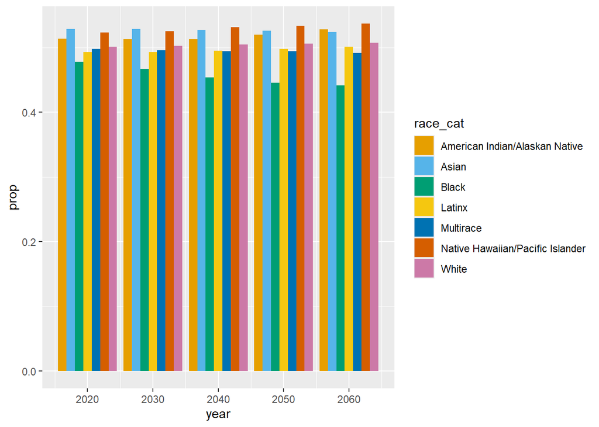

```r
dof %>%
  filter(sex == "Female" &
           year %in% seq(from = 2020, to = 2060, by = 10)) %>%
  ggplot(aes(x = year, y = prop, fill = race_cat)) +
  geom_bar(position = "dodge", stat = "identity") +
  see::scale_fill_okabeito()
```

A far better options is to use small multiples and make one chart per race/ethnicity group.

To do this, we’ll use `facet_wrap`. The first argument is the categorical variable for which you want one chart per category. This variable should have a tilde (`~`) in front of it. Then you can use the `ncol` or `nrow` arugments to specify the number of rows or columns you want to display the small multiples. You can use both `ncol` and `nrow` if you want, but don’t need to use both.

```r
plot <- ggplot(dof) +
  geom_line(aes(x = year, y = prop, group = sex, color = sex),
            size = 1.5) +
  facet_wrap(~race_cat,
             nrow = 4)
plot
```

[figure not shown]

Now, all that’s left is to make the chart look nicer.

We can set colors for the categories, adjust the overall appearance, change the y-axis scale and add a descriptive title.

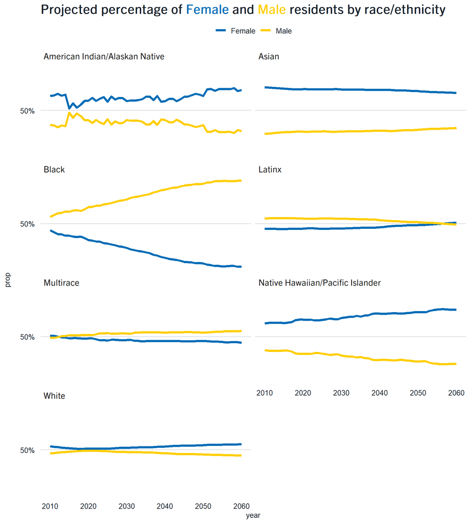

```r
# set the colors we want to use in our chart
male_color <- "#ffce00"
female_color <- "#006cb6"

plot_title <- gg_color_title(title_text = "Projected percentage of Female and Male residents by race/ethnicity",
                             highlight_words = c("Female", "Male"),
                             highlight_colors = c(female_color, male_color))

plot1 <- plot +
  scale_color_manual(values = c("Female" = female_color, "Male" = male_color)) +
  scale_y_continuous(labels = scales::percent,
                     breaks = 0.5) +
  theme_gg_smc() +
  labs(title = plot_title)
plot1
```